# Data Wrangling

Priyanga Talagala

```r
library(tidyverse)
library(lubridate)
```

This report demonstrates variety of processes used to transform raw data into more readily used formats.

## Study area

- Pringle Creek, NEON (National Ecological Observatory Network) aquatic sites located in Wise County, Texas, USA
- NEON usually has two sensor locations on any river in the network where water quality is measured using in-situ sensors.
- In Pringle Creek, these locations are situated about 200 m apart.

[figure not shown]

```r
# This is a working script to remove wiper anomalies occurs at every 5th  observation
# load data (setwd to the source file location)

load(here::here("data", "data-raw", "flagged-data", "waq_down.rda"))
load(here::here("data", "data-raw", "flagged-data", "waq_up.rda"))
#load(here::here("data", "data-raw", "EOS_5_min.rda"))
#load(here::here("data", "data-raw", "TSW_5min.rda"))

waq_strm_cols <- c("specificConductance", "dissolvedOxygen", "pH",
                   "turbidity", "chlorophyll", "fDOM")
waq_anomaly_flag <- c("conductanceAnomalyFlag", "dissolvedOxygenAnomalyFlag",
                      "pHAnomalyFlag", "turbidityAnomalyFlag",
                      "chlorophyllAnomalyFlag", "fDOMAnomalyFlag")

waq_down <- waq_down %>%
  filter(Timestamp >= ymd("2019-07-01") & Timestamp < ymd("2020-01-01"))
waq_up <- waq_up %>%
  filter(Timestamp >= ymd("2019-07-01") & Timestamp < ymd("2020-01-01"))

waq_up <- waq_up %>%
  mutate(turbidity = if_else(turbidityAnomalyFlag == 1, as.numeric(NA),
                             turbidity),
         specificConductance = if_else(conductanceAnomalyFlag == 1,
                                       as.numeric(NA), specificConductance),
         pH = if_else(pHAnomalyFlag == 1, as.numeric(NA),
                      pH),
         dissolvedOxygen = if_else(dissolvedOxygenAnomalyFlag == 1,
                                   as.numeric(NA), dissolvedOxygen),
         chlorophyll = if_else(chlorophyllAnomalyFlag == 1,
                               as.numeric(NA), chlorophyll),
         fDOM = if_else(fDOMAnomalyFlag == 1, as.numeric(NA),
                        fDOM))

waq_down <- waq_down %>%
  mutate(turbidity = if_else(turbidityAnomalyFlag == 1, as.numeric(NA),
                             turbidity),
         specificConductance = if_else(conductanceAnomalyFlag == 1,
                                       as.numeric(NA), specificConductance),
         pH = if_else(pHAnomalyFlag == 1, as.numeric(NA),
                      pH),
         dissolvedOxygen = if_else(dissolvedOxygenAnomalyFlag == 1,
                                   as.numeric(NA), dissolvedOxygen),
         chlorophyll = if_else(chlorophyllAnomalyFlag == 1,
                               as.numeric(NA), chlorophyll),
         fDOM = if_else(fDOMAnomalyFlag == 1, as.numeric(NA),
                        fDOM))
```

```r
data_turb_up <- waq_up %>%
  select(Timestamp, turbidity) %>%
  mutate(turbidity_diff = turbidity - lag(turbidity, n = 1L),
         turbidity_max = zoo::rollmax(turbidity, k = 5, fill = NA,
                                      align = "right"),
         wiper_flag = if_else(turbidity == turbidity_max, 1, 0),
         wiper_flag = if_else(is.na(wiper_flag), 0, wiper_flag))

data_turb_down <- waq_down %>%
  select(Timestamp, turbidity) %>%
  mutate(turbidity_diff = turbidity - lag(turbidity, n = 1L),
         turbidity_max = zoo::rollmax(turbidity, k = 5, fill = NA,
                                      align = "right"),
         wiper_flag = if_else(turbidity == turbidity_max, 1, 0),
         wiper_flag = if_else(is.na(wiper_flag), 0, wiper_flag))
```

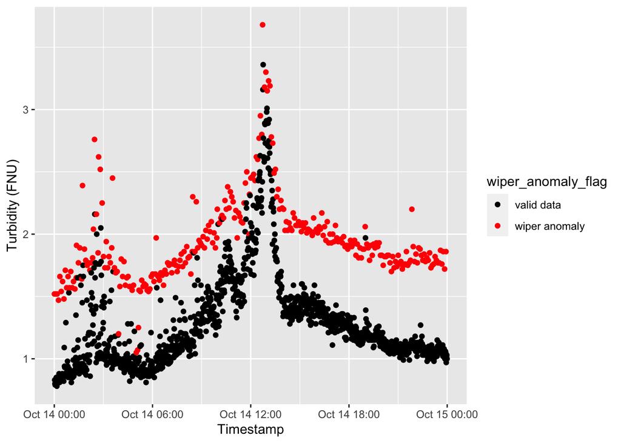

```r
## ---- timeplots-flagged-anomalies

waq_up_sub <- waq_up %>%
  select(Timestamp, turbidity, turbidityAnomalyFlag, turbidity_wiperAnomalyFlag,
         specificConductance, conductanceAnomalyFlag, dissolvedOxygen,
         dissolvedOxygenAnomalyFlag) %>%
  filter(Timestamp >= ymd("2019-10-01") & Timestamp < ymd("2020-01-01"))

waq_down_sub <- waq_down %>%
  select(Timestamp, turbidity, turbidityAnomalyFlag,
         turbidity_wiperAnomalyFlag) %>%
  filter(Timestamp >= ymd("2019-10-01") & Timestamp < ymd("2020-01-01"))


## ---- wiper-anomaly

waq_down_sub %>%
  filter(Timestamp >= ymd("2019-10-14") & Timestamp < ymd("2019-10-15")) %>%
  mutate(wiper_anomaly_flag = factor(turbidity_wiperAnomalyFlag,
                                     levels = c(0,1),
                                     labels = c("valid data", "wiper anomaly"))) %>%
  ggplot(aes(Timestamp, turbidity,
             color = wiper_anomaly_flag)) +
  geom_point() +
  ylab("Turbidity (FNU)") +
  scale_color_manual(values = c("black", "red"))
```

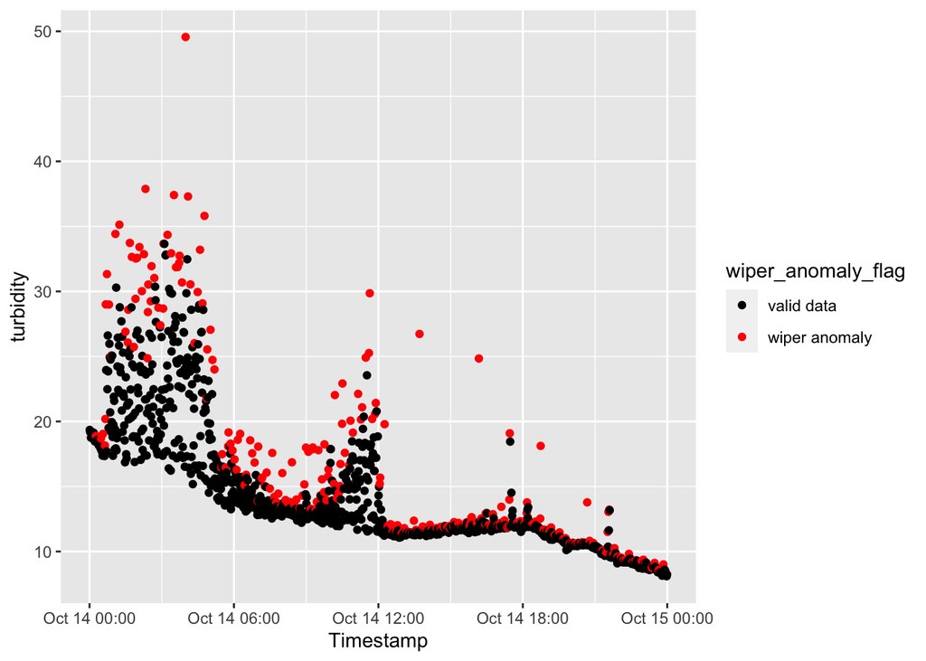

```r
waq_up_sub %>%
  filter(Timestamp >= ymd("2019-10-14") & Timestamp < ymd("2019-10-15")) %>%
  mutate(wiper_anomaly_flag = factor(turbidity_wiperAnomalyFlag,
                                     levels = c(0,1),
                                     labels = c("valid data", "wiper anomaly"))) %>%
  ggplot(aes(Timestamp, turbidity,
             color = wiper_anomaly_flag)) +
  geom_point() +
  scale_color_manual(values = c("black", "red"))
```

```r
load(here::here("data", "data-raw", "EOS_5_min.rda"))
load(here::here("data", "data-raw", "TSW_5min.rda"))

load(here::here("data", "data-raw", "waq_instantaneous.rda"))
load(here::here("data", "data-raw", "variables_20288.rda"))
```